# Logistic Regression Project

Benard Omido

2024-03-20

```r
library(tidyverse)
library(broom)
library(fst)
```

Load the data

```r
churn <- read_fst("churn.fst")
glimpse(churn)
```

```
## Rows: 400
## Columns: 3
## $ has_churned               <int> 0, 0, 0, 0, 0, 0, 0, 0, 0, 0, 0, 0, 0, 0, 0,…
## $ time_since_first_purchase <dbl> -1.08922097, 1.18298297, -0.84615637, 0.0869…
## $ time_since_last_purchase  <dbl> -0.72132150, 3.63443539, -0.42758226, -0.535…
```

Check for null values

```r
#The data set has no null values

colSums(is.na(churn))
```

```
##               has_churned time_since_first_purchase  time_since_last_purchase
##                         0                         0                         0
```

Get the summary statistics using skimr

```r
skimr::skim(churn)
```

Data summary

| Name | churn |
| --- | --- |
| Number of rows | 400 |
| Number of columns | 3 |
| _______________________ |  |
| Column type frequency: |  |
| numeric | 3 |
| ________________________ |  |
| Group variables | None |

**Variable type: numeric**

| skim_variable | n_missing | complete_rate | mean | sd | p0 | p25 | p50 | p75 | p100 | hist |
| --- | --- | --- | --- | --- | --- | --- | --- | --- | --- | --- |
| has_churned | 0 | 1 | 0.50 | 0.50 | 0.00 | 0.00 | 0.50 | 1.00 | 1.00 | ▇▁▁▁▇ |
| time_since_first_purchase | 0 | 1 | -0.03 | 0.95 | -1.27 | -0.83 | -0.15 | 0.54 | 3.74 | ▇▆▂▁▁ |
| time_since_last_purchase | 0 | 1 | 0.14 | 1.10 | -0.87 | -0.65 | -0.27 | 0.57 | 5.93 | ▇▂▁▁▁ |

In this project, I use a logistic regression model to predict whether a customer will churn given the time they made their first purchase to the company.

**Understanding the variables of interest**

- has_churned: response variable (1 = churned, 0 = didn’t churn)
- time_since_first_purchase: explanatory variable (time)

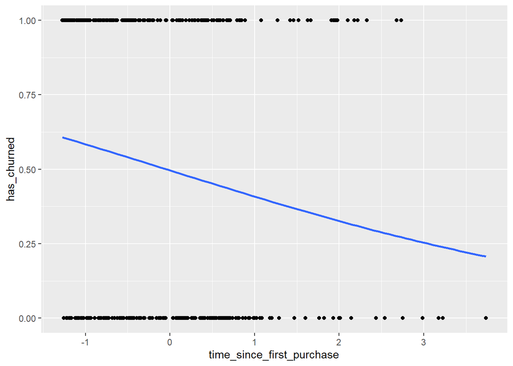

```r
#A scatter plot to check the relationship between time_since_first_purchase and has_churned

p1 <- ggplot(churn, aes(time_since_first_purchase, has_churned)) +
  geom_point() +
  geom_smooth(method = "glm", se = FALSE, method.args = list(family = binomial))

p1
```

The scatter plot above shows a negative relationship between the response and explanatory variable. As time since first purchase increases, the likelihood of churning decreases. This implies that longer customer tenure or loyalty is associated with a lower likelihood of churning.

**Fitting a model**

```r
mdl_time_churn <- glm(has_churned ~ time_since_first_purchase, data = churn, family = "binomial")
summary(mdl_time_churn)
```

```
##
## Call:
## glm(formula = has_churned ~ time_since_first_purchase, family = "binomial",
##     data = churn)
##
## Coefficients:
##                           Estimate Std. Error z value Pr(>|z|)
## (Intercept)               -0.01518    0.10156  -0.150  0.88115
## time_since_first_purchase -0.35479    0.11095  -3.198  0.00139 **
## ---
## Signif. codes:  0 '***' 0.001 '**' 0.01 '*' 0.05 '.' 0.1 ' ' 1
##
## (Dispersion parameter for binomial family taken to be 1)
##
##     Null deviance: 554.52  on 399  degrees of freedom
## Residual deviance: 543.73  on 398  degrees of freedom
## AIC: 547.73
##
## Number of Fisher Scoring iterations: 4
```

**Interpretation**

- The intercept term represents the log-odds of churning when the time since the first purchase is zero. A -0.01518 intercept indicates a negative log-odds. However, since the p-value > 0.05, it suggests that the intercept is not statistically significant, meaning it may not have a practical interpretation without considering other factors.
- A -0.35479 represents the change in log-odds of churning for a one-unit increase in time since the first purchase while holding other variables constant. As the time since the first purchase increases by one unit, the log-odds of churning decrease by approximately 0.35479 units. Customers who have been with the company longer are less likely to churn compared to newer customers
- In this model, the residual deviance is lower than the null deviance, suggesting that the model provides a better fit than the null model

**Making Predictions Using the Model**

```r
#Create a data frame that holds explanatory data that is within the churn data set range

summary(churn$time_since_first_purchase)
```

```
##     Min.  1st Qu.   Median     Mean  3rd Qu.     Max.
## -1.27377 -0.82838 -0.15207 -0.03437  0.54483  3.73831
```

```r
explanatory_data <- tibble(time_since_first_purchase = seq(-1.3, 3.8, 0.1))
head(explanatory_data)
```

```
## # A tibble: 6 × 1
##   time_since_first_purchase
##                       <dbl>
## 1                      -1.3
## 2                      -1.2
## 3                      -1.1
## 4                      -1
## 5                      -0.9
## 6                      -0.8
```

```r
#Use predict() on the fitted model to get the predicted values
model_predictions <- explanatory_data %>%
  mutate(has_churned = predict(mdl_time_churn, explanatory_data, type = "response")
         )

head(model_predictions)
```

```
## # A tibble: 6 × 2
##   time_since_first_purchase has_churned
##                       <dbl>       <dbl>
## 1                      -1.3       0.610
## 2                      -1.2       0.601
## 3                      -1.1       0.593
## 4                      -1         0.584
## 5                      -0.9       0.575
## 6                      -0.8       0.567
```

Adding the above predicted data to the plot to see how well it fits

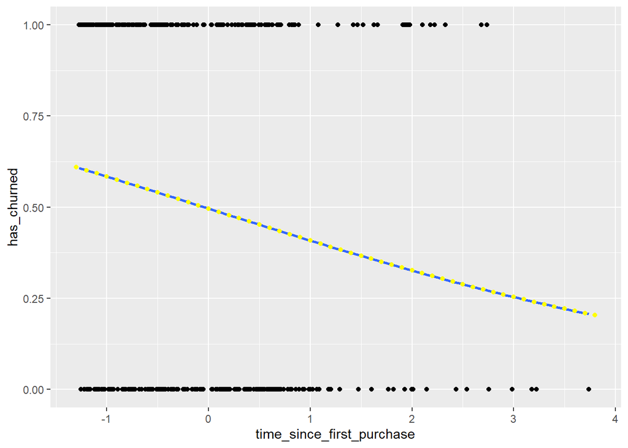

```r
p1 <- p1 +
  geom_point(data = model_predictions, color = "yellow")

p1
```

**Most likely outcome**

```r
#Add the most likely outcome column to model_predictions data frame

model_predictions <- explanatory_data %>%
  mutate(has_churned = predict(mdl_time_churn, explanatory_data, type = "response"),
         most_likely_outcome = round(has_churned)
  )

head(model_predictions)
```

```
## # A tibble: 6 × 3
##   time_since_first_purchase has_churned most_likely_outcome
##                       <dbl>       <dbl>               <dbl>
## 1                      -1.3       0.610                   1
## 2                      -1.2       0.601                   1
## 3                      -1.1       0.593                   1
## 4                      -1         0.584                   1
## 5                      -0.9       0.575                   1
## 6                      -0.8       0.567                   1
```

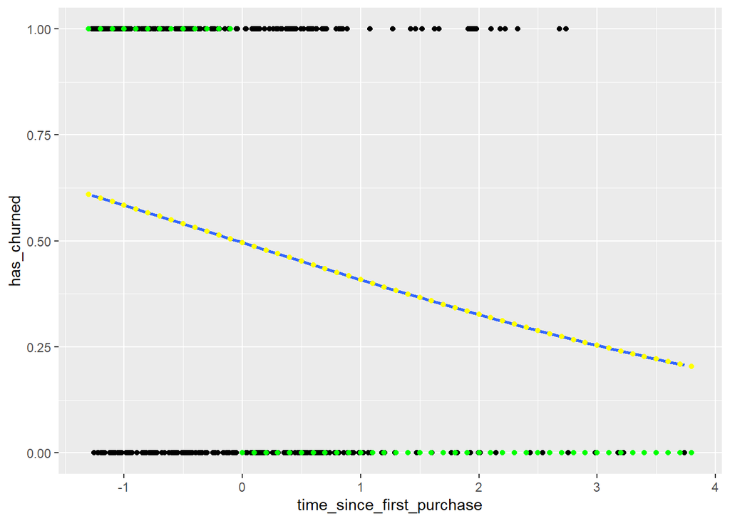

```r
#Visualizing the most likely outcome

p1 <- p1 +
  geom_point(aes(y = most_likely_outcome), data = model_predictions,
             color = "green")

p1
```

**Odds ratio** - probability of something happening divided by the probability that it doesn’t

```r
#Calculating odds ratio and adding it to the data frame

model_predictions <- explanatory_data %>%
  mutate(has_churned = predict(mdl_time_churn, explanatory_data, type = "response"),
         most_likely_outcome = round(has_churned),
         odds_ratio = has_churned / (1 - has_churned)
  )

head(model_predictions)
```

```
## # A tibble: 6 × 4
##   time_since_first_purchase has_churned most_likely_outcome odds_ratio
##                       <dbl>       <dbl>               <dbl>      <dbl>
## 1                      -1.3       0.610                   1       1.56
## 2                      -1.2       0.601                   1       1.51
## 3                      -1.1       0.593                   1       1.46
## 4                      -1         0.584                   1       1.40
## 5                      -0.9       0.575                   1       1.36
## 6                      -0.8       0.567                   1       1.31
```